# project

## STAT 319 Capstone Project - Classification

Team: Nabeel Ahmed, Saiid Koroma, and Hideki Shie

## Importing Libraries

```python
import numpy as np
import pandas as pd
import seaborn as sns
import matplotlib.pyplot as plt
from sklearn.preprocessing import LabelEncoder
from sklearn.model_selection import train_test_split
from sklearn.preprocessing import StandardScaler
from sklearn.metrics import accuracy_score,confusion_matrix,classification_report,ConfusionMatrixDisplay
from sklearn.linear_model import LogisticRegression
from sklearn.model_selection import GridSearchCV
```

## Data Cleaning

Cleaning data is a crucial step in the process of data analysis. Espically with large datasets, like the one we are working with, it is important to ensure that the data is clean and ready for analysis. Unclean data can lead to biases, incorrect conclusions, and other issues that can affect the validity of the results.

```python
# import the dataset
df = pd.read_csv("COVID-19_Case_Surveillance_Public_Use_Data_2023.csv")
df.head()
```

|  | cdc_case_earliest_dt | cdc_report_dt | pos_spec_dt | onset_dt | current_status | sex | age_group | race_ethnicity_combined | hosp_yn | icu_yn | death_yn | medcond_yn |
| --- | --- | --- | --- | --- | --- | --- | --- | --- | --- | --- | --- | --- |
| 0 | 2023/01/02 | 2023/01/10 | NaN | 2023/01/02 | Laboratory-confirmed case | Male | 10 - 19 Years | Black, Non-Hispanic | No | No | No | Yes |
| 1 | 2023/01/02 | 2023/01/04 | 2023/01/04 | 2023/01/02 | Probable Case | Male | 10 - 19 Years | Black, Non-Hispanic | No | Missing | No | Missing |
| 2 | 2023/01/02 | 2023/01/02 | NaN | NaN | Laboratory-confirmed case | Male | 10 - 19 Years | Black, Non-Hispanic | Missing | Missing | Missing | Missing |
| 3 | 2023/01/02 | 2023/01/11 | 2023/01/02 | NaN | Probable Case | Male | 10 - 19 Years | Black, Non-Hispanic | Missing | Missing | No | Missing |
| 4 | 2023/01/02 | 2023/01/04 | 2023/01/02 | NaN | Laboratory-confirmed case | Male | 10 - 19 Years | Black, Non-Hispanic | Missing | Missing | Missing | Unknown |

```python
# display a summar of the dataset datatypes
df.info()
```

```
<class 'pandas.core.frame.DataFrame'>
RangeIndex: 4663475 entries, 0 to 4663474
Data columns (total 12 columns):
 #   Column                   Dtype
---  ------                   -----
 0   cdc_case_earliest_dt     object
 1   cdc_report_dt            object
 2   pos_spec_dt              object
 3   onset_dt                 object
 4   current_status           object
 5   sex                      object
 6   age_group                object
 7   race_ethnicity_combined  object
 8   hosp_yn                  object
 9   icu_yn                   object
 10  death_yn                 object
 11  medcond_yn               object
dtypes: object(12)
memory usage: 427.0+ MB
```

```python
# create a new column "Race"
df['Race'] = df['race_ethnicity_combined'].str.split(',').str[0]
# list all unique races in the dataset
df['Race'].unique()
```

```
array(['Black', 'Unknown', 'Hispanic/Latino', 'White',
       'Native Hawaiian/Other Pacific Islander',
       'American Indian/Alaska Native', 'Missing', 'Multiple/Other',
       'Asian'], dtype=object)
```

```python
# Create a new dataframe with current_status, sex, age_group, Race, hosp_yn, icu_yn, death_yn, medcond_yn columns as the variables
new_df = df[[
    'current_status',
    'sex',
    'age_group',
    'Race',
    'hosp_yn',
    'icu_yn',
    'death_yn',
    'medcond_yn',
]].copy()
```

```python
# Replace "Missing" and "Unknown" labels with "NaN"
new_df = new_df.replace("Missing", np.nan)
new_df = new_df.replace("Unknown", np.nan)

# Remove all NaN rows
new_df = new_df.dropna()
```

```python
# Row count of cleaned dataset
print(f"Dataset has {new_df.shape[0]} rows.")
```

```
Dataset has 29727 rows.
```

## Data Visualization

Visualizing data is an important part of data analysis as it allows us to visually explore the data to gain insights and understand the patterns. Large datasets can be overwhelming and difficult to interpret, so it is important to use visualizations to simplify the data and make it easier to understand.

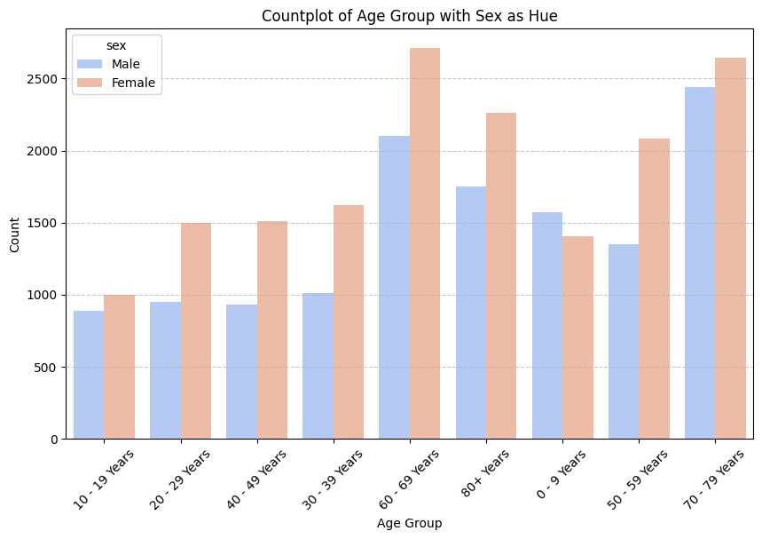

```python
#Create a countplot for the age_group column with sex column as the hue.
plt.figure(figsize=(10, 6))
sns.countplot(data=new_df, x="age_group", hue="sex", palette="coolwarm")

plt.xlabel("Age Group")
plt.ylabel("Count")
plt.title("Countplot of Age Group with Sex as Hue")
plt.xticks(rotation=45)
plt.grid(axis="y", linestyle="--", alpha=0.7)


plt.show()
```

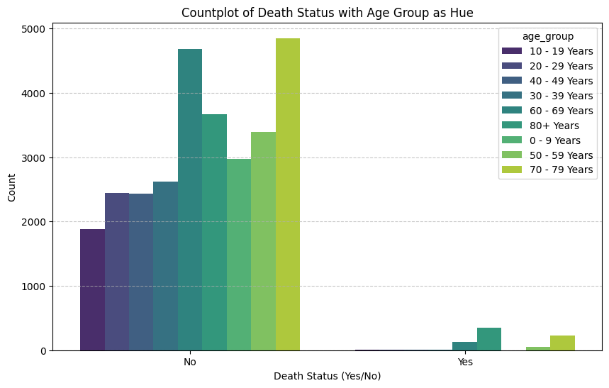

```python
#Create a countplot for the death_yn column with age_group column as the hue.
plt.figure(figsize=(10, 6))
sns.countplot(data=new_df, x="death_yn", hue="age_group", palette="viridis")

plt.xlabel("Death Status (Yes/No)")
plt.ylabel("Count")
plt.title("Countplot of Death Status with Age Group as Hue")
plt.grid(axis="y", linestyle="--", alpha=0.7)


plt.show()
```

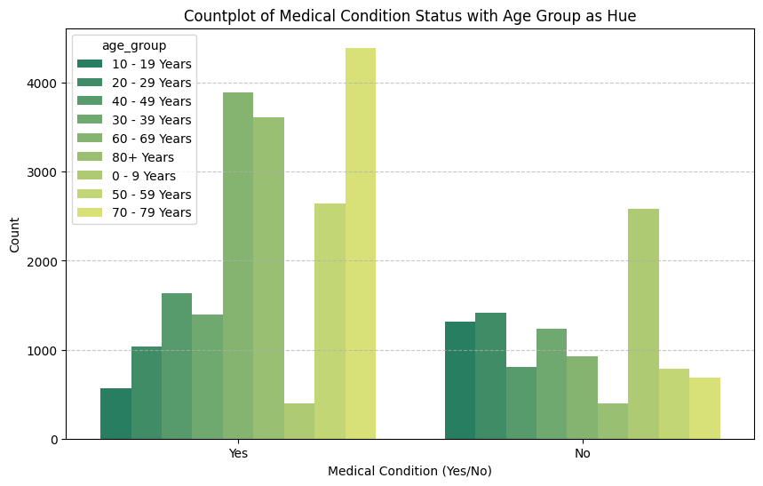

```python
#Create a countplot for the medcond_yn column with age_group column as the hue.

plt.figure(figsize=(10, 6))
sns.countplot(data=new_df, x="medcond_yn", hue="age_group", palette="summer")

plt.xlabel("Medical Condition (Yes/No)")
plt.ylabel("Count")
plt.title("Countplot of Medical Condition Status with Age Group as Hue")
plt.grid(axis="y", linestyle="--", alpha=0.7)

plt.show()
```

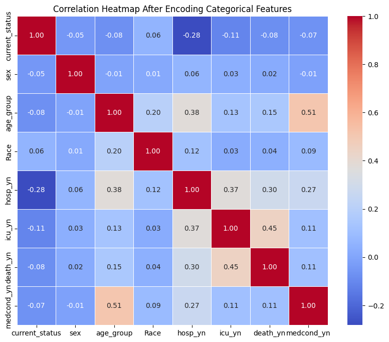

```python
#Encode the categorical values using the LabelEncoder() module. Create a heatmap of the correlation between the columns (features).


label_encoder = LabelEncoder()

categorical_columns = new_df.select_dtypes(include=['object']).columns
for col in categorical_columns:
    new_df[col] = label_encoder.fit_transform(new_df[col])


correlation_matrix = new_df.corr()


plt.figure(figsize=(10, 8))
sns.heatmap(correlation_matrix, annot=True, cmap="coolwarm", fmt=".2f", linewidths=0.5)


plt.title("Correlation Heatmap After Encoding Categorical Features")


plt.show()
```

## Training and Prediction

Once you have cleaned and visualized your data, you can train a model to predict the outcome of a patient's disease. The models we will train are going to predict whether a person will survive or die from an infection.

```python
# Separate the Target(death_yn column) as y from the predictors (Remaining columns) as X.
X = new_df.drop('death_yn',axis=1)
y = new_df['death_yn']
```

```python
# Using the train_test_split module, split the data into 80% training set and 20 % test set. Use a random_state seed of 42.
X_train, X_test, y_train, y_test = train_test_split(X, y, test_size=0.2, random_state=42)
```

```python
# Train Logistic Regression with a random_state seed of 42.
lr_model = LogisticRegression(random_state=42)
lr_model.fit(X_train, y_train)
```

```
LogisticRegression(random_state=42)
```

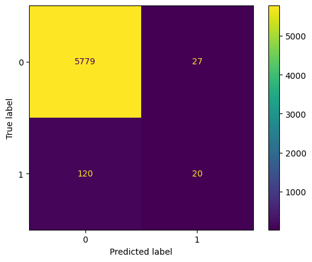

```python
# Get the Confusion Matrix Plot for the model.
y_pred = lr_model.predict(X_test)
cm = confusion_matrix(y_test,y_pred)

disp = ConfusionMatrixDisplay(confusion_matrix=cm, display_labels=lr_model.classes_)
disp.plot()
plt.show()
```

```python
print(classification_report(y_test,y_pred, zero_division=0))
```

```
              precision    recall  f1-score   support

           0       0.98      1.00      0.99      5806
           1       0.43      0.14      0.21       140

    accuracy                           0.98      5946
   macro avg       0.70      0.57      0.60      5946
weighted avg       0.97      0.98      0.97      5946
```

```python
lr_model2 = LogisticRegression(random_state=42)

C = np.logspace(0, 4, 10)

# the following parameter GridSearchCV will search over the parameter space
param_grid = [
    {'penalty': ['l2'], 'solver': ['lbfgs', 'sag'], 'C': C},
    {'penalty': ['l1', 'l2'], 'solver': ['liblinear', 'saga'], 'C': C}
]

grid_model = GridSearchCV(lr_model2, param_grid=param_grid, cv = 10)
```

```python
grid_model.fit(X_train, y_train)
```

```
GridSearchCV(cv=10, estimator=LogisticRegression(random_state=42),
             param_grid=[{'C': array([1.00000000e+00, 2.78255940e+00, 7.74263683e+00, 2.15443469e+01,
       5.99484250e+01, 1.66810054e+02, 4.64158883e+02, 1.29154967e+03,
       3.59381366e+03, 1.00000000e+04]),
                          'penalty': ['l2'], 'solver': ['lbfgs', 'sag']},
                         {'C': array([1.00000000e+00, 2.78255940e+00, 7.74263683e+00, 2.15443469e+01,
       5.99484250e+01, 1.66810054e+02, 4.64158883e+02, 1.29154967e+03,
       3.59381366e+03, 1.00000000e+04]),
                          'penalty': ['l1', 'l2'],
                          'solver': ['liblinear', 'saga']}])
```

```python
grid_model.best_params_
```

```
{'C': np.float64(1.0), 'penalty': 'l2', 'solver': 'liblinear'}
```

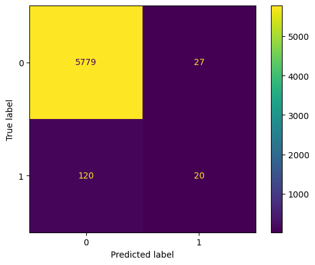

```python
# Get the Confusion Matrix Plot for the model.
y_pred = grid_model.predict(X_test)
cm = confusion_matrix(y_test,y_pred)

disp = ConfusionMatrixDisplay(confusion_matrix=cm)
disp.plot()
plt.show()
```

```python
print(classification_report(y_test,y_pred, zero_division=0))
```

```
              precision    recall  f1-score   support

           0       0.98      1.00      0.99      5806
           1       0.43      0.14      0.21       140

    accuracy                           0.98      5946
   macro avg       0.70      0.57      0.60      5946
weighted avg       0.97      0.98      0.97      5946
```

# Comparing the Two Models

The behaviors of the models were the same. Both models had the same amount of true positives, false positives, false negatives, and true negatives. As a result of this, they also had the same weighted average of precision, recall, and f-1 score.